# Logistics individual work- Forecast

Alex Romanenko

4 February 2017

#### **General Approach**

The report will be based on data from 4 US stores.

### **1. Data preparation**

#### **1.1 Missing values check**

By manipulating the provided data I have come up with the final 4 data sets per each store, which shows amount of lettuce used per store per day in ounces.

First of all, let’s look at the data per store: Ninth Street, Berkeley (cal1- 46673); Shattuck Sq, Berkeley (cal2- 4904); Myrtle Avenue, Ridgewood (ny1- 12631) and Whitney Avenue, Elmhurst(ny2- 20974).

```
##    4904 12631 20974 46673
## 1     0   232     0   152
## 2     0   227     4   100
## 3     0   181     0    54
## 4     0   221     0   199
## 5     0   229     0   166
## 6     0   237     0   143
## 7     0   235     0   162
## 8     0   244     0   116
## 9   176   218    29   136
## 10  182   205     0    68
## 11  347   248     0   176
## 12  400   153     6   181
## 13  406   222     8   120
## 14  382   262     4   141
## 15  324   259     0   205
## 16  192   274   164   118
## 17  274   250   112    62
## 18  370   209   168   152
```

We can clearly see that for stores 4904 and 20974 there are some missing values. Therefore, for the purpose of this exercise, I will use data starting from 13/03/15 for 4904 and data starting from 20/03/15 for 20974. There are no other missing values to deal with at this point.

#### **1.2 Outliers check**

Next step is to check if there are any outliers, which might affect training of our model. The outliers will be checked by normalising the values in data frames using z-score and highlighting if there are any absolute values higher than 3.

Z- normalisation test shows that Whitney Avenue, Elmhurst (ny2) has two potential outliers on 15-04-04 and 15-06-11. Let’s see if these outliers ‘stand out’ when plotting the time series:

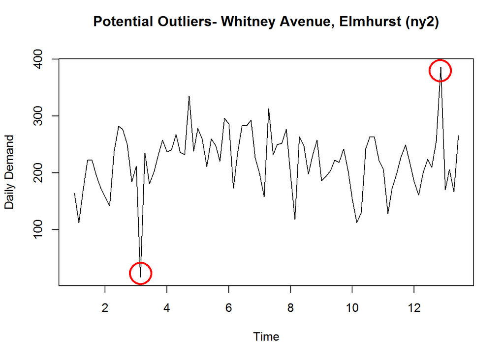

We can clearly see that for ny2 plot, the two values are outliers, therefore in order to ensure that forecasts are not skewed, I will replace these values with averages for respective weekdays over the ny2 time series:

Based on the means (which exclude outliers), we get the following ‘new’ values for the days where outliers are observed:

15-04-04 - 167 15-06-11 - 233

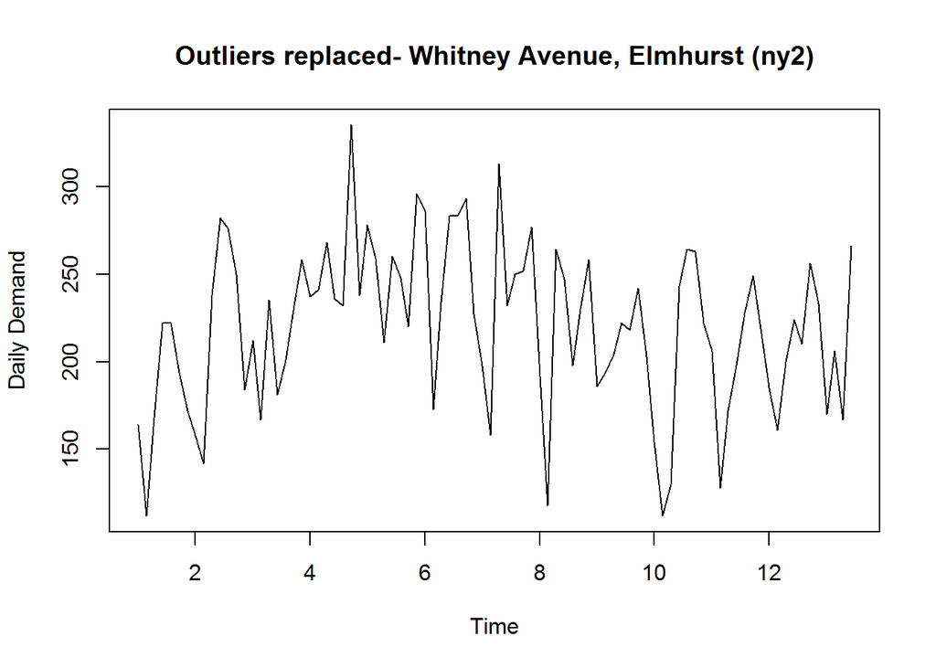

We can see from the plot above that the graph looks much better (no clear outliers). The data is now ready to be used for forecasts.

#### **1.3 Training/ Validation split**

As discussed above, the data sets for the 4 stores will be split into a training and validation sets with validation sets consisting of last 3 weeks of the time series.

### **2. Model training**

#### **2.1 Holt-Winters method**

I will start training the model by applying Holt-Winters method to the 4 data sets. Holt-Winters method aims to calculate optimal alpha (error type), beta (trend type) and gamma (seasonality) by minimising sum of squared errors.

I will use the following steps for every one of the 4 stores:

1. To better understand nature of the demand fluctuations, I will decompose a time series into seasonal, trend and irregular components using loess (stl function). This information will be used to set parameters of predictive models.
2. Application of Holt-Winters model using *HoltWinters* and *ets* functions.

#### **Myrtle Avenue, Ridgewood (ny1)**

**1. Demand Decomposition**

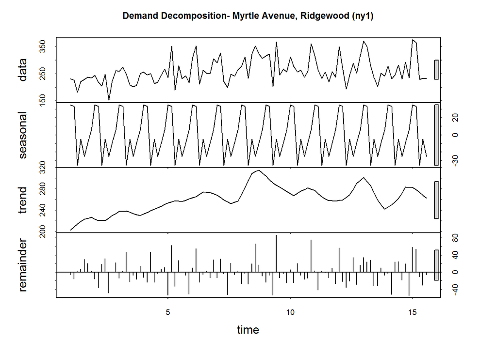

Findings: Seasonality: There is a clear seasonality, however the impact is not very significant. Trend: There is a slight increase in demand around weeks 8 and 9, after which the trend somewhat stabilised towards the end of the period. The variation is constant with relative significance Remainder: The error is relatively significant

**2 Holt Winters & ETS**

As discussed above, the seasonality will not be taken into account when estimating the demand using HW model. While for ETS an automatic selection will be used (ZZZ as parameters)

```
## Holt-Winters exponential smoothing with trend and without seasonal component.
##
## Call:
## HoltWinters(x = ny1.train, gamma = FALSE)
##
## Smoothing parameters:
##  alpha: 0.1114312
##  beta : 0.1760316
##  gamma: FALSE
##
## Coefficients:
##         [,1]
## a 252.112018
## b  -2.219709
```

Low value for alpha (0.111) indicates that the estimate of the demand will be based on observations throughout the time series (as opposed to simply basing it on last few weeks). Low beta (0.176) indicates lack of trend. Gamma was set as FALSE as there appear to be insignificant seasonality.

```
## ETS(M,N,M)
##
## Call:
##  ets(y = ny1.train, model = "ZZZ")
##
##   Smoothing parameters:
##     alpha = 0.1436
##     gamma = 1e-04
##
##   Initial states:
##     l = 226.187
##     s=1.0368 0.9597 0.931 1.0028 0.8576 1.1207
##            1.0914
##
##   sigma:  0.1353
##
##      AIC     AICc      BIC
## 960.5539 963.6524 984.6210
```

The most suitable ETS model (M,N,M) indicates results similar to the HW model, where the trend should not be taken into account using the predict model.However the seasonality, together with error parameter is set to be multiplicative.

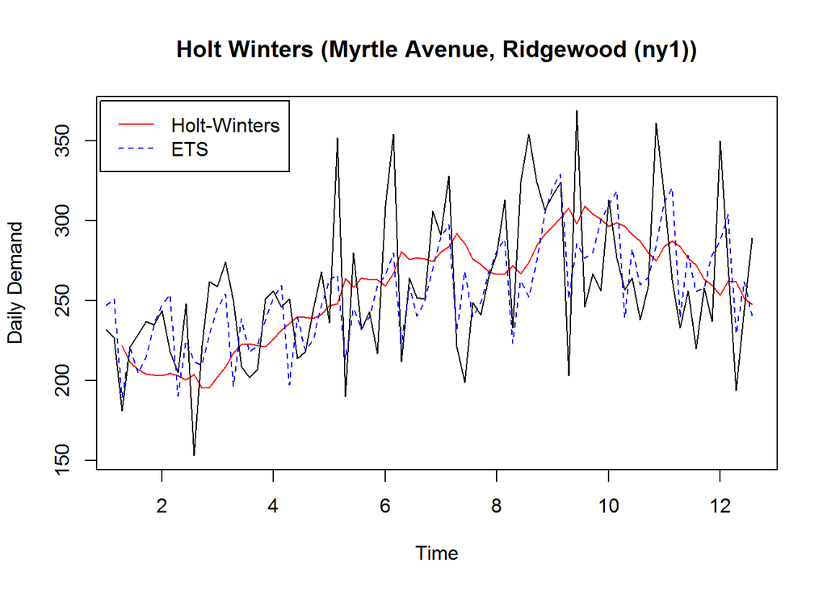

The plot above shows that both HW and ETS produce similar results based on the demand of a training data set.

#### **Whitney Avenue, Elmhurst (ny2)**

**1. Demand Decomposition**

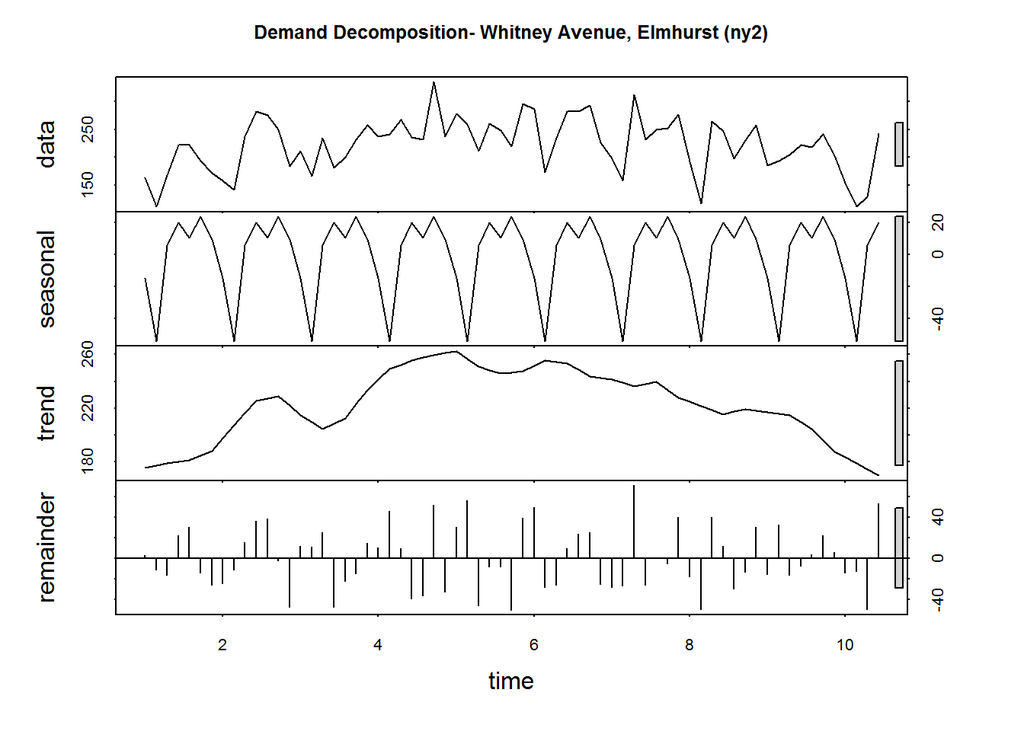

**2 Holt Winters & ETS**

Based on the above observations, the seasonality will not be taken into account when estimating the demand using HW model. For ETS an automatic selection will be used (ZZZ as parameters)

```
## Holt-Winters exponential smoothing with trend and without seasonal component.
##
## Call:
## HoltWinters(x = ny2.train, gamma = FALSE)
##
## Smoothing parameters:
##  alpha: 0.6412046
##  beta : 0.1530094
##  gamma: FALSE
##
## Coefficients:
##         [,1]
## a 197.150660
## b   1.286696
```

```
## ETS(M,A,A)
##
## Call:
##  ets(y = ny2.train, model = "ZZZ")
##
##   Smoothing parameters:
##     alpha = 0.0186
##     beta  = 0.0186
##     gamma = 1e-04
##
##   Initial states:
##     l = 164.8643
##     b = 4.2311
##     s=7.8035 23.6119 8.705 21.7741 14.1658 -49.6824
##            -26.3779
##
##   sigma:  0.1551
##
##      AIC     AICc      BIC
## 781.4228 787.2006 807.8791
```

The most suitable ETS model (M,A,A) indicates results different to hw model. Interestingly the automatic ETS model have chosen to include seasonality and the trend as additive parameters. The error parameter is set to be multiplicative

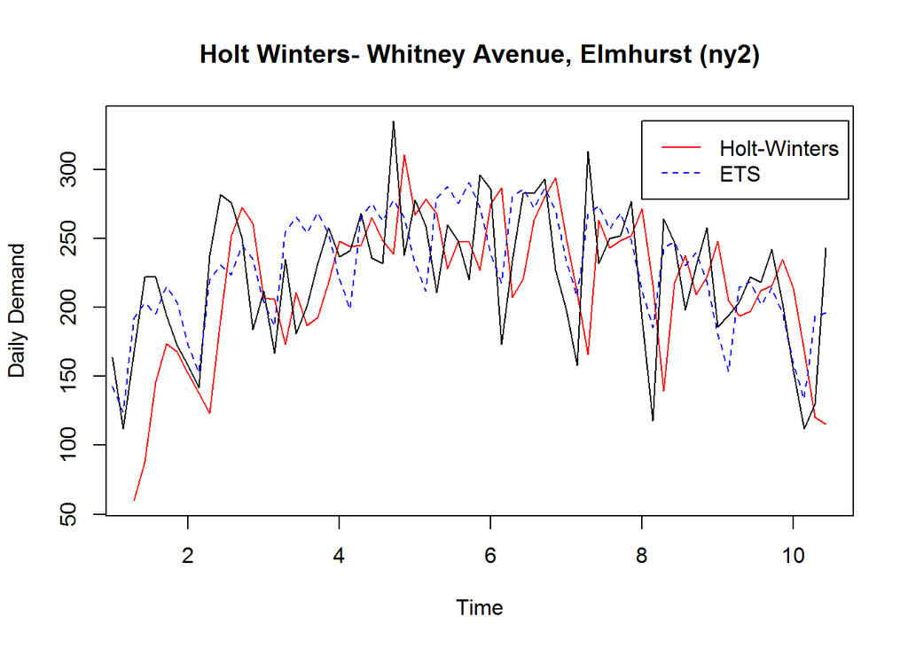

The plot above shows that both HW and ETS produce similar results.

#### **Ninth Street, Berkeley (cal1)**

**1. Demand Decomposition**

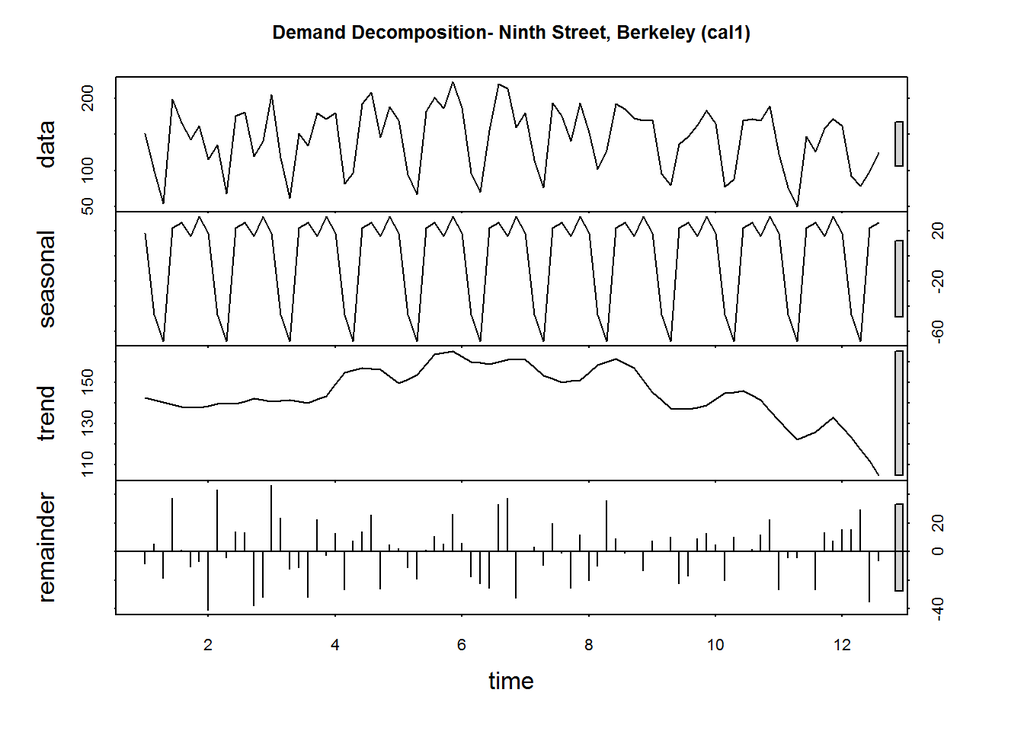

**2 Holt Winters & ETS**

The seasonality will be taken into account when estimating the demand using HW model. While for ETS an automatic selection will be used (ZZZ as parameters)

```
## Holt-Winters exponential smoothing with trend and additive seasonal component.
##
## Call:
## HoltWinters(x = cal1.train)
##
## Smoothing parameters:
##  alpha: 0.06275704
##  beta : 0
##  gamma: 0.3791712
##
## Coefficients:
##           [,1]
## a  121.4806235
## b   -0.2993197
## s1  32.2126962
## s2  47.2532556
## s3  22.8604904
## s4 -43.3451474
## s5 -55.5975742
## s6   7.1491331
## s7  15.4174910
```

Extremely low value for alpha (0.063) indicates that the estimate of the demand will be based on observations throughout the time series. Beta is equals to 0, which confirms our initial observation that the slope of the trend should not be taken into account- according to the model it is not represented over the time series and is set to be equal to its initial value. Gamma is relatively low (0.379), which indicates that the seasonality prediction will be based on majority of observations in the time series.

```
## ETS(A,N,A)
##
## Call:
##  ets(y = cal1.train, model = "ZZZ")
##
##   Smoothing parameters:
##     alpha = 0.1221
##     gamma = 1e-04
##
##   Initial states:
##     l = 142.8872
##     s=32.4047 17.5048 26.4602 23.4956 -68.6444 -48.62
##            17.3992
##
##   sigma:  23.1968
##
##      AIC     AICc      BIC
## 896.9694 900.0680 921.0366
```

The most suitable ETS model (A,N,A) indicates results similar to the HW model, trend set to N and error trend and seasonality are set to additive.

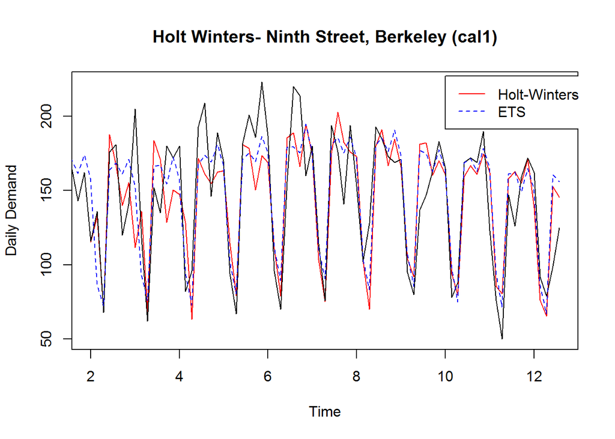

The plot above shows that both HW and ETS produce very similar results when analysing the demand of a training data set.

#### **Shattuck Sq, Berkeley (cal2)**

**1. Demand Decomposition**

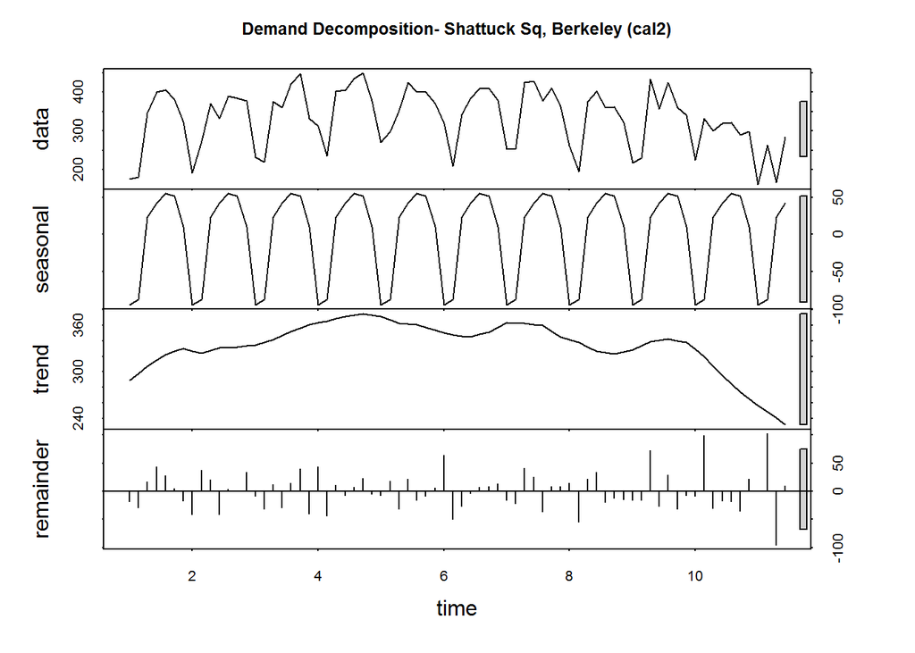

Findings: Seasonality: There is a clear seasonality and although it is not as significant as for cal1, there is still some sense to include it in our prediction model. Trend: Overall the trend changes a lot over time. The significance level is low and therefore trend impact should not be used in the predictive model. Remainder: The error is relatively significant (although less than for other stores).

#### **2 Holt Winters & ETS**

The seasonality will be taken into account when estimating the demand using HW model. While for ETS an automatic selection will be used (ZZZ as parameters).

```
## Holt-Winters exponential smoothing with trend and additive seasonal component.
##
## Call:
## HoltWinters(x = cal2.train)
##
## Smoothing parameters:
##  alpha: 0.1746077
##  beta : 0.08714941
##  gamma: 0.6471552
##
## Coefficients:
##           [,1]
## a   269.082365
## b    -4.854094
## s1   23.462966
## s2   -2.949784
## s3   -4.568768
## s4 -125.571484
## s5  -42.079336
## s6  -67.522260
## s7   11.346009
```

```
## ETS(A,A,A)
##
## Call:
##  ets(y = cal2.train, model = "ZZZ")
##
##   Smoothing parameters:
##     alpha = 0.0125
##     beta  = 0.0119
##     gamma = 0.001
##
##   Initial states:
##     l = 313.9676
##     b = 3.6739
##     s=12.5936 51.3338 54.4933 42.5226 24.3219 -86.2043
##            -99.0608
##
##   sigma:  39.5452
##
##      AIC     AICc      BIC
## 886.7626 891.8773 914.4114
```

The most suitable ETS model (A,A,A) indicates results similar to the HW model except for the trend, which is set to Additive as well as error trend and seasonality.

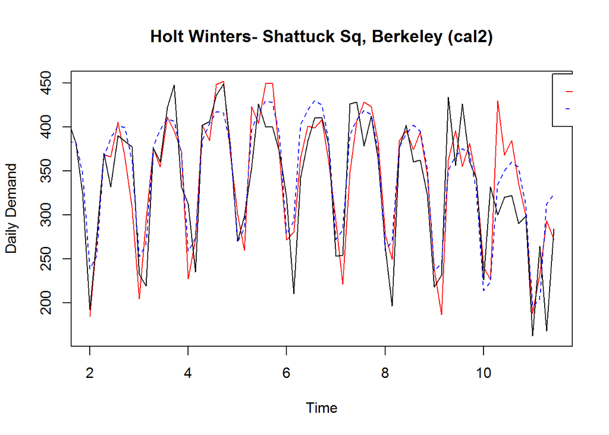

The plot above shows that both HW and ETS produce very similar results when analysing the demand of a training data set.

#### **3.2 ARIMA method**

The method for ARIMA model includes the following steps:

1. Identification. The time series will be tested for stationarity. If required, n differentiation will be performed to make it stationary.
2. Estimation. AUTOARIMA function will be used. This step will also include testing based on maximum likelihood estimators.
3. Verification. The model will be tested using residual analysis and assessed based on the conducted tests.

#### **Myrtle Avenue, Ridgewood (ny1)**

**1. Identification**

Results of the test show the following: Required differencing: 1 required seasonal differencing: 0

Following the first level of differencing, both adf and pp tests (p values < 0.01) show that the time series is now stationary.

The next step is to test the time series on autocorrelations using ACF (Autocorrelation Function). The autocorrelations is one indication that ARIMA could potentially model the time series. PACF (Partial Autocorrelation Function) is another tool, which is used for revealing correlations within time series. q (Moving averages) and p (autoregression) coefficients will be estimated using these approaches

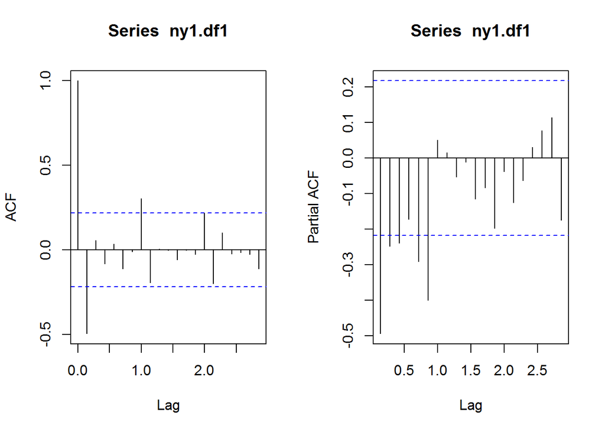

We can see from the graph above that for Myrtle Avenue, Ridgewood (ny1), the model should have q <=5 and p <=4

**2.Estimation**

By Running auto.arima() function, we have the following model with the best BIC score:

Series: ny1.train ARIMA(0,1,1)(1,0,0)[7]

Coefficients: ma1 sar1 -0.9115 0.3425 s.e. 0.0480 0.1090

sigma^2 estimated as 1656: log likelihood=-415.25 AIC=836.51 AICc=836.82 BIC=843.69

It is important to note that these parameters fit findings of the ‘identification’ section.

#### **3. Model Validation**

**3.1 Model Fit**

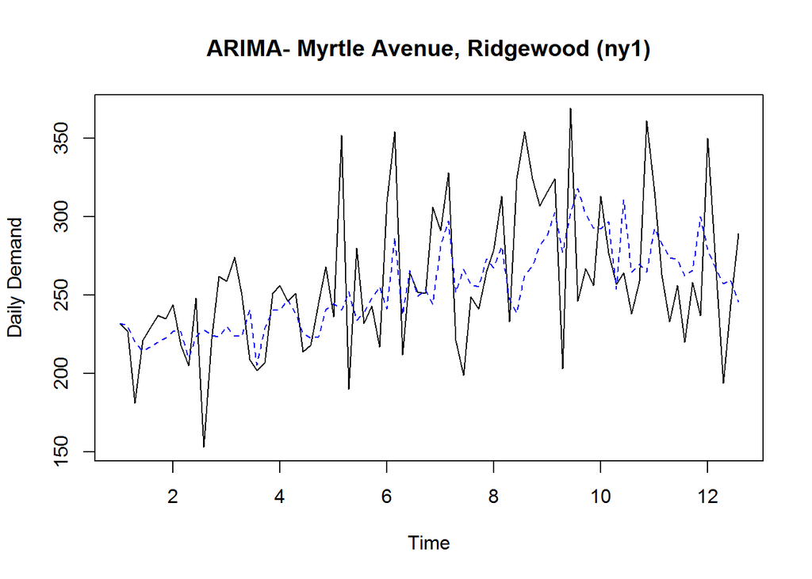

From the graph above, we can see that ARIMA model follows the training set well.

**3.2 Model Residuals Diagnostic**

The model diagnostic will be conducted by looking at 3 areas: 1. Standardised Residuals. Ideally we do not want to see any clusters of volatility 2. ACF shows no significant correlation between the residuals 3. Ljung-Box statistics. We want to see p-values above the interval. This will indicate that there is no pattern in the residuals

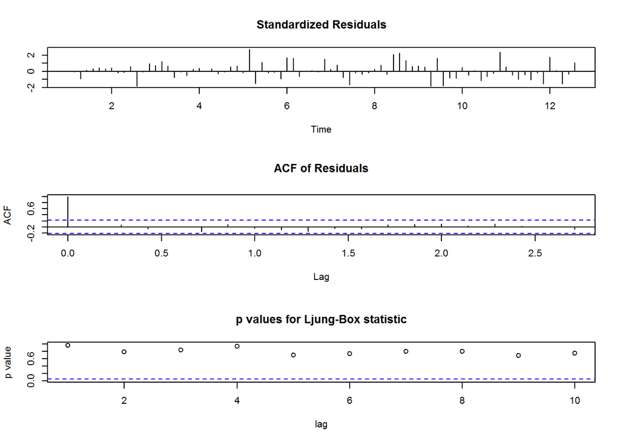

The graphs show: 1. Stadardised Residuals: No clusters of volatility for standardised residuals 2. ACF of residuals: No significant correlation between the residuals 3. p values for L-B statistics: all p values are large- no pattern in residuals.

Based on the above analysis, the model is fit for purpose.

#### **Whitney Avenue, Elmhurst (ny2)**

**1. Identification**

Results of the test show the following: Required differencing: 0 required seasonal differencing: 1

After testing the model with no differentiation- adf test rejected null hypothesis (being stationary), where pp test failed to reject it. Following the first level of differencing, both adf and pp tests (p values < 0.01) show that the time series is now stationary.

The next step is to test the time series on autocorrelations using ACF (Autocorrelation Function):

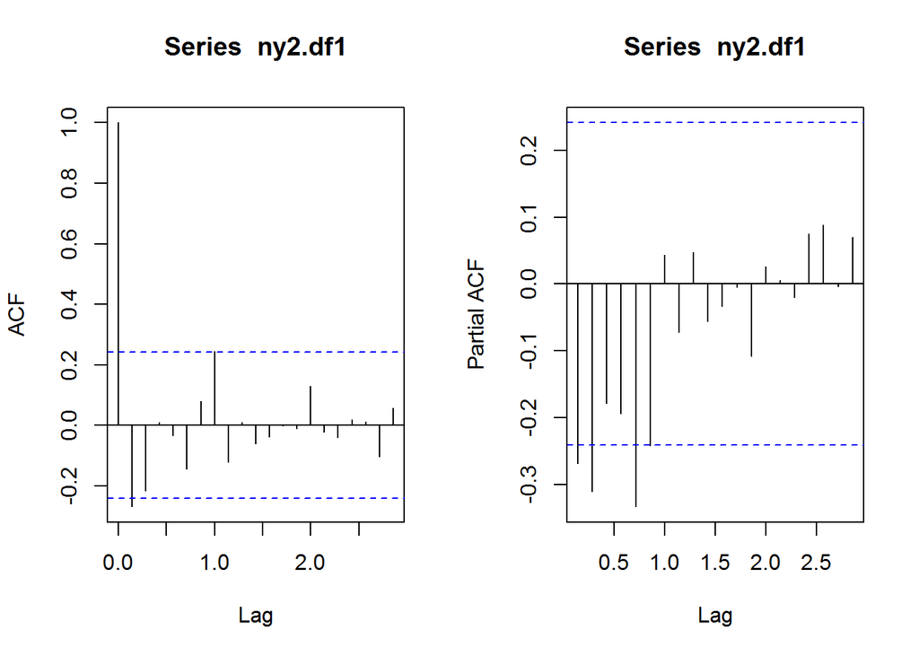

We can see from the graph above that for Whitney Avenue, Elmhurst (ny2), the model should have q <=2 and p <=2

**2.Estimation**

By Running auto.arima() function, we have the following model with the best BIC score:

Series: ny2.train ARIMA(0,1,1)(0,1,1)[7]

Coefficients: ma1 sma1 -0.7675 -0.8735 s.e. 0.0915 0.3707

sigma^2 estimated as 1787: log likelihood=-308.94 AIC=623.89 AICc=624.33 BIC=630.12

It is important to note that these parameters fit findings of the ‘identification’ section.

#### **3. Model Validation**

**3.1 Model Fit**

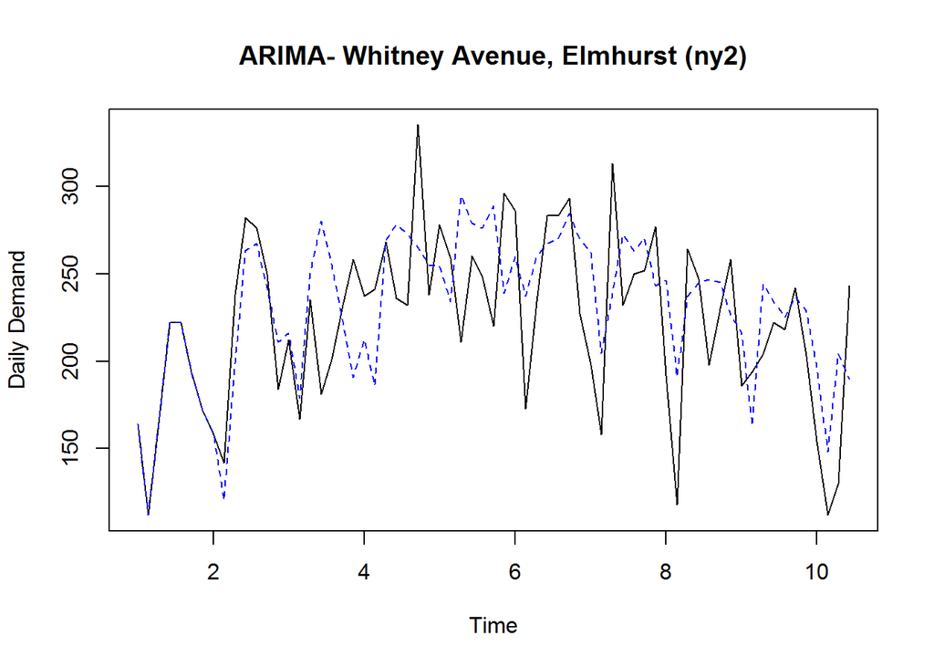

From the graph above, we can see that ARIMA model follows the training set well.

**3.2 Model Residuals Diagnostic**

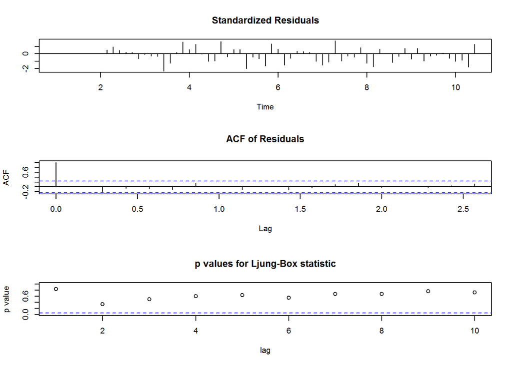

The graphs show: 1. Stadardised Residuals: No clusters of volatility for standardised residuals 2. ACF of residuals: No significant correlation between the residuals 3. p values for L-B statistics: most p values are large- no clear pattern in residuals.

Based on the above analysis, the model is fit for purpose.

#### **Ninth Street, Berkeley (cal1)**

**1. Identification**

Results of the test show the following: Required differencing: 0 required seasonal differencing: 0

The tests show that there is no need in differentiating the data series. After testing the model with no differentiation- both adf and pp tests confirmed stationarity.

The next step is to test the time series on autocorrelations using ACF (Autocorrelation Function):

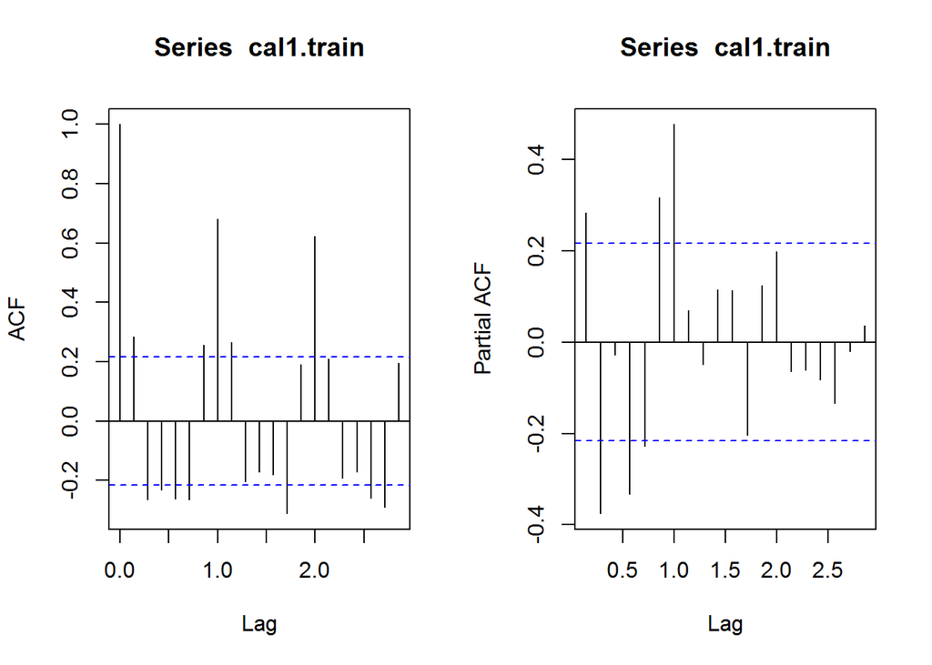

We can see from the graph above that for Ninth Street, Berkeley (cal1) there are a number of autocorrelations present. The model should have q <=11 and p <=4.

**2.Estimation**

By Running auto.arima() function, we have the following model with the best BIC score:

Series: cal1.train ARIMA(0,0,0)(2,0,0)[7] with non-zero mean

Coefficients: sar1 sar2 intercept 0.4192 0.4292 137.1715 s.e. 0.0965 0.1017 12.6231

sigma^2 estimated as 750.1: log likelihood=-390.39 AIC=788.78 AICc=789.3 BIC=798.41

It is important to note that these parameters fit findings of the ‘identification’ section.

**3.1 Model Fit**

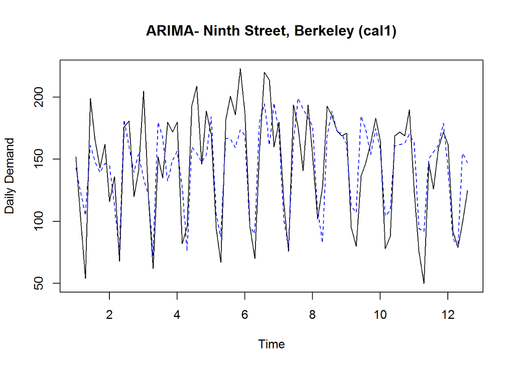

From the graph above, we can see that ARIMA model follows the training set well.

**3.2 Model Residuals Diagnostic**

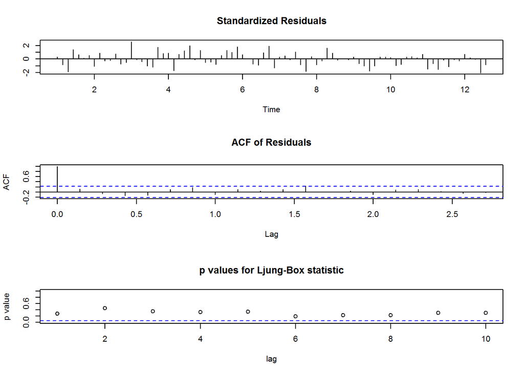

The graphs show: 1. Stadardised Residuals: No clusters of volatility for standardised residuals 2. ACF of residuals: No significant correlation between the residuals, however there is one minor autocorrelation present 3. p values for L-B statistics: most p values are still above the threshold, but not by much- no clear pattern in residuals.

Based on the above analysis, the model is fit for purpose. The fitness is not as strong as the models for ny1 and ny2, so it will be interesting to see how this model performs on the validation set.

#### **Shattuck Sq, Berkeley (cal2)**

**1. Identification**

Results of the test show the following: Required differencing: 0 required seasonal differencing: 1

After testing the model with no differentiation- both adf and pp tests (p values < 0.01) show that the time series is stationary.

The next step is to test the time series on autocorrelations using ACF (Autocorrelation Function):

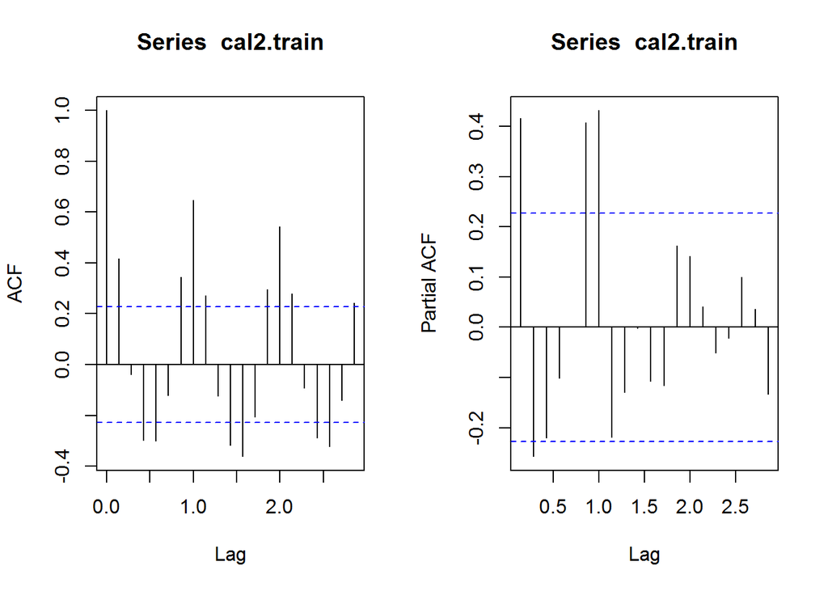

We can see from the graph above that for Shattuck Sq, Berkeley (cal2), the model should have q <=13 and p <=3

**2.Estimation**

By Running auto.arima() function, we have the following model with the best BIC score:

Series: cal2.train ARIMA(0,1,1)(0,1,1)[7]

Coefficients: ma1 sma1 -0.8133 -0.4955 s.e. 0.0769 0.1643

sigma^2 estimated as 2203: log likelihood=-348.3 AIC=702.6 AICc=702.99 BIC=709.17

#### **Model Validation**

**3.1 Model Fit**

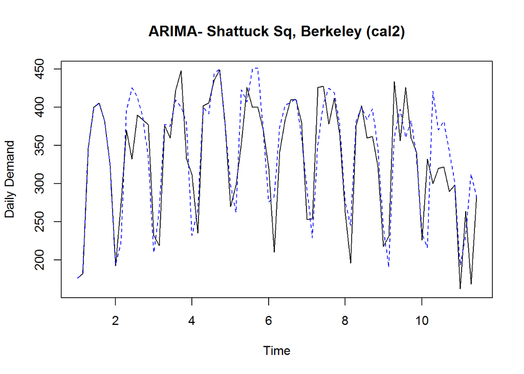

From the graph above, we can see that ARIMA model follows the training set well.

**3.2 Model Residuals Diagnostic**

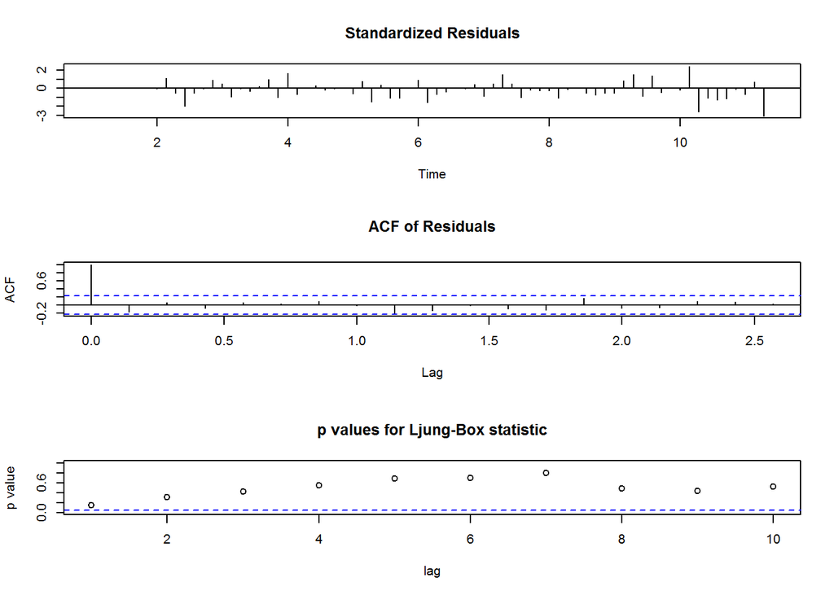

The graphs show: 1. Stadardised Residuals: No clusters of volatility for standardised residuals 2. ACF of residuals: No significant correlation between the residuals, although one of the lags is very close to the threshold 3. p values for L-B statistics: most p values (except for 1) are large- no clear pattern in residuals.

Based on the above analysis, the model is fit for purpose.

### **3. Model Validation**

#### **3.1 Model Training Summary**

Based on the analysis described in the section 2, I propose to test and validate the following models:

| Store | Store No. | Holt-W | Holt-W (EST) | ARIMA |
| --- | --- | --- | --- | --- |
| ny1 | 12631 | default: gamma = FALSE | ETS(M,N,M) | ARIMA(0,1,1)(1,0,0)[7] |
| ny2 | 20974 | default: gamma= FALSE | ETS(M,A,A) | ARIMA(0,1,1)(0,1,1)[7] |
| cal1 | 46673 | default: gamma= TRUE | ETS(A,N,A) | ARIMA(0,0,0)(2,0,0)[7] |
| cal2 | 4904 | default: gamma= TRUE | ETS(A,A,A) | ARIMA(0,1,1)(0,1,1)[7] |

In this section I will apply these models to the validation set. The performance will be assessed by comparing RMSE (Residual Mean Squared Errors) for the forecasted time series comparing the validation set.

**3.2 Model Validation Assessment**

#### **Myrtle Avenue, Ridgewood (ny1)**

Forecast of the demand values for the next 3 weeks using the chosen models produces the following:

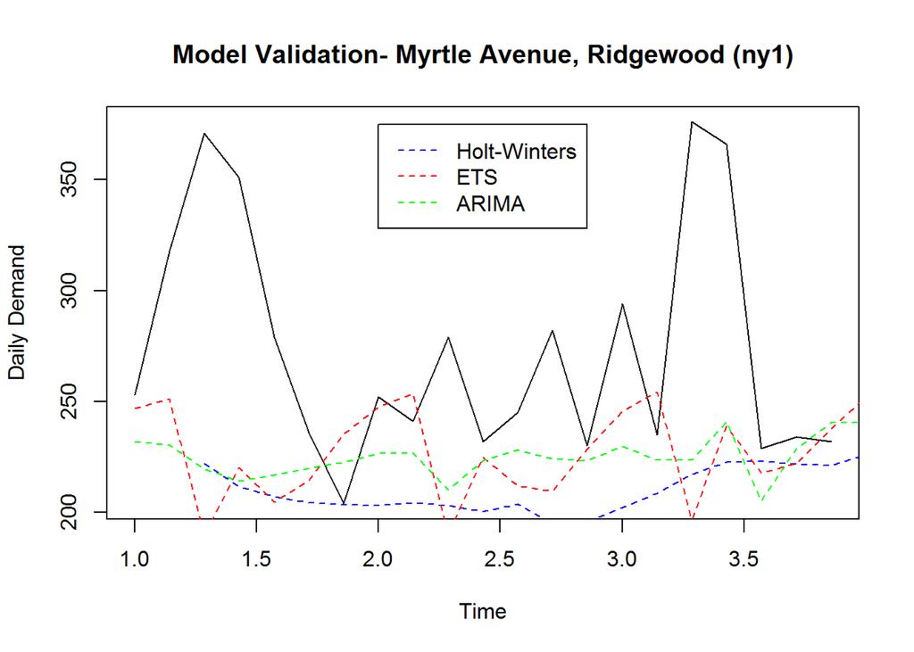

Based on the chart above- all 3 models have somewhat forecasted the values below the validation set. Here are the results of the forecasts:

```
##            Actuals  HW ETS ARIMA
## 2015-05-27     253 250 255   263
## 2015-05-28     318 248 276   255
## 2015-05-29     371 245 290   294
## 2015-05-30     351 243 298   267
## 2015-05-31     279 241 228   241
## 2015-06-01     236 239 267   258
## 2015-06-02     204 237 248   273
## 2015-06-03     252 234 255   264
## 2015-06-04     241 232 276   262
## 2015-06-05     279 230 290   275
## 2015-06-06     232 228 298   266
## 2015-06-07     245 225 228   257
## 2015-06-08     282 223 267   263
## 2015-06-09     230 221 248   268
## 2015-06-10     294 219 255   265
## 2015-06-11     235 217 276   264
## 2015-06-12     376 214 290   268
## 2015-06-13     366 212 298   265
## 2015-06-14     229 210 228   262
## 2015-06-15     234 208 267   264
## 2015-06-16     232 205 248   266
```

**Whitney Avenue, Elmhurst (ny2)**

Forecast of the demand values for the next 3 weeks using the chosen models produces the following:

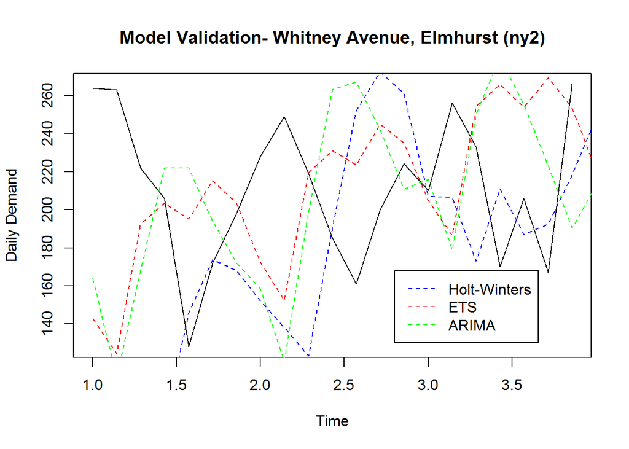

Results of the forecasts:

```
##            Actuals  HW ETS ARIMA
## 2015-05-27     264 198 180   196
## 2015-05-28     263 200 192   211
## 2015-05-29     222 201 173   198
## 2015-05-30     206 202 135   168
## 2015-05-31     128 204 108   129
## 2015-06-01     172 205 169   188
## 2015-06-02     198 206 173   205
## 2015-06-03     228 207 156   194
## 2015-06-04     249 209 168   209
## 2015-06-05     219 210 149   195
## 2015-06-06     185 211 111   166
## 2015-06-07     161 213  84   127
## 2015-06-08     200 214 145   185
## 2015-06-09     224 215 149   203
## 2015-06-10     210 216 133   192
## 2015-06-11     256 218 144   206
## 2015-06-12     233 219 125   193
## 2015-06-13     170 220  87   164
## 2015-06-14     206 222  61   125
## 2015-06-15     167 223 121   183
## 2015-06-16     266 224 125   201
```

**Ninth Street, Berkeley (cal1)**

Forecast of the demand values for the next 3 weeks using the chosen models produces the following:

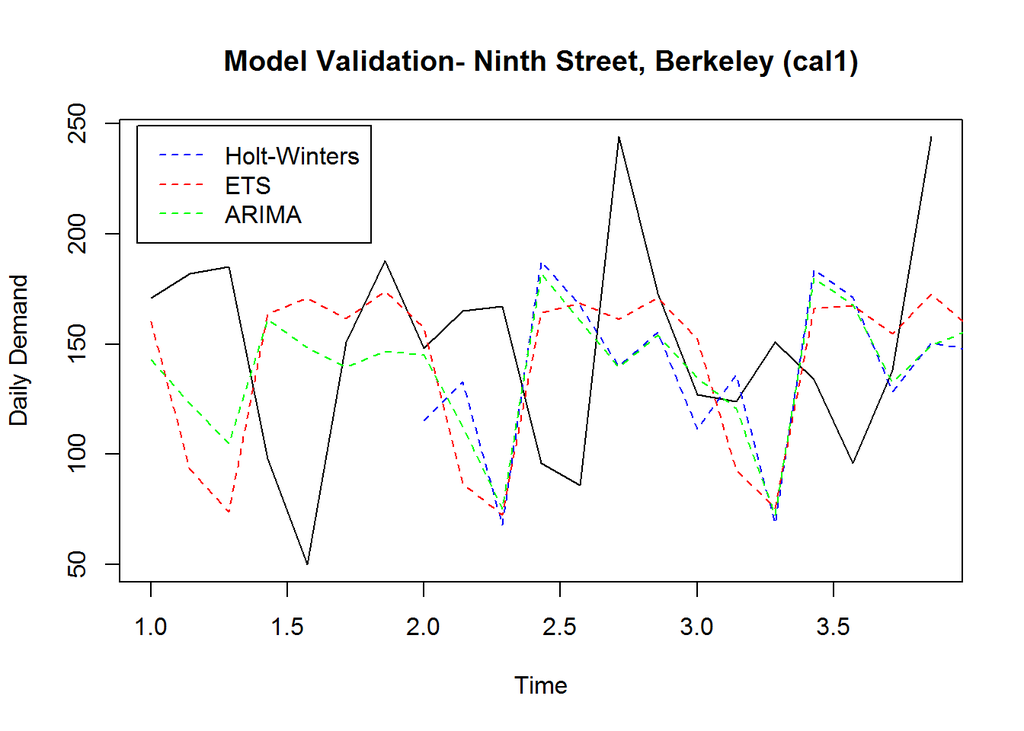

Results of the forecasts:

```
##            Actuals  HW ETS ARIMA
## 2015-05-27     171 153 143   160
## 2015-05-28     182 168 158   174
## 2015-05-29     185 143 143   141
## 2015-05-30      98  77  77    92
## 2015-05-31      50  64  57    75
## 2015-06-01     151 127 149   125
## 2015-06-02     188 135 152   127
## 2015-06-03     148 151 143   156
## 2015-06-04     165 166 158   168
## 2015-06-05     167 141 143   150
## 2015-06-06      96  75  77    99
## 2015-06-07      86  62  57    86
## 2015-06-08     244 125 149   116
## 2015-06-09     173 133 152   128
## 2015-06-10     127 149 143   155
## 2015-06-11     124 164 158   166
## 2015-06-12     151 139 143   144
## 2015-06-13     134  73  77   102
## 2015-06-14      96  60  57    89
## 2015-06-15     138 123 149   123
## 2015-06-16     244 131 152   129
```

**Shattuck Sq, Berkeley (cal2)**

Forecast of the demand values for the next 3 weeks using the chosen models produces the following:

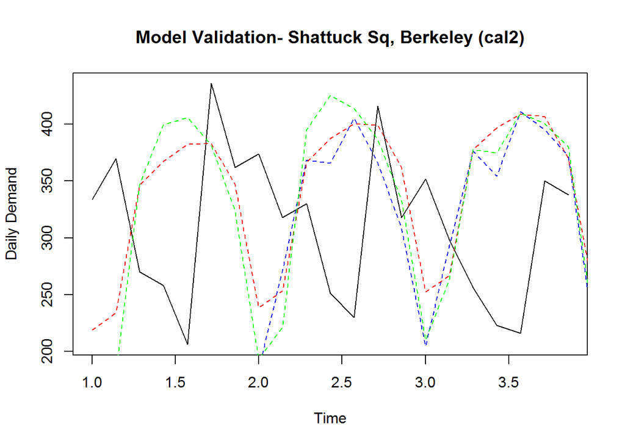

Results of the forecasts:

```
##            Actuals  HW ETS ARIMA
## 2015-05-27     334 288 330   294
## 2015-05-28     370 256 321   263
## 2015-05-29     270 250 277   252
## 2015-05-30     258 124 160   130
## 2015-05-31     206 203 167   204
## 2015-06-01     436 172 273   192
## 2015-06-02     362 246 285   249
## 2015-06-03     374 254 292   259
## 2015-06-04     318 222 284   229
## 2015-06-05     330 216 239   218
## 2015-06-06     251  90 122    96
## 2015-06-07     230 169 130   169
## 2015-06-08     416 138 235   158
## 2015-06-09     318 212 248   215
## 2015-06-10     352 220 254   225
## 2015-06-11     298 188 246   195
## 2015-06-12     256 182 202   184
## 2015-06-13     223  56  85    61
## 2015-06-14     216 135  92   135
## 2015-06-15     350 104 197   124
## 2015-06-16     338 178 210   180
```

**3.3 Model Validation Summary**

Based on the analysis described in the section 2, I propose to test and validate the following models:

[output not shown]

### **4. Forecast**

Based on the selected optimal models and their parameters, the prediction for the next two weeks will be performed by applying the models to the the whole period (training + validation sets):

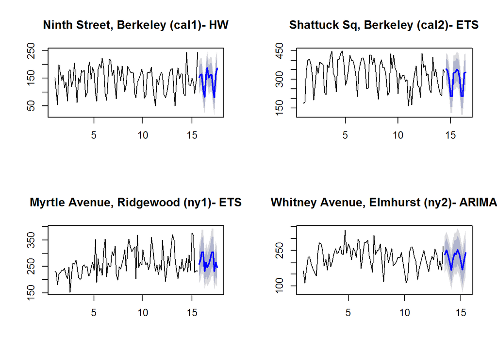

**Final forecast results (in ounces):**

```
##            California 1 (ID:46673) California 2 (ID:4904)
## 2015-06-16                     154                    354
## 2015-06-17                     164                    345
## 2015-06-18                     164                    301
## 2015-06-19                     107                    213
## 2015-06-20                      82                    213
## 2015-06-21                     165                    334
## 2015-06-22                     187                    338
## 2015-06-23                     152                    353
## 2015-06-24                     163                    344
## 2015-06-25                     163                    300
## 2015-06-26                     106                    211
## 2015-06-27                      81                    212
## 2015-06-28                     164                    333
## 2015-06-29                     186                    337
##            New York 1 (ID:12631) New York 2 (ID:20974)
## 2015-06-16                   259                   233
## 2015-06-17                   277                   250
## 2015-06-18                   304                   231
## 2015-06-19                   305                   199
## 2015-06-20                   232                   167
## 2015-06-21                   266                   209
## 2015-06-22                   247                   238
## 2015-06-23                   259                   235
## 2015-06-24                   277                   252
## 2015-06-25                   304                   233
## 2015-06-26                   305                   201
## 2015-06-27                   232                   169
## 2015-06-28                   266                   211
## 2015-06-29                   247                   240
```